# Social Media Data Analysis

Ashita Shetty

```r
library(readr)
library(corpcor)
library(Hotelling)
library(lattice)
library(ggplot2)
library(ggridges)
library(ggvis)
library(ggthemes)
library(cowplot)
library(gapminder)
library(gganimate)
library(dplyr)
library(tidyverse)
library(grid)
library(gridExtra)
library(RColorBrewer)

library(cluster)
library(readr)
library(factoextra)
library(FactoMineR)
library(magrittr)
library(NbClust)
library(psych)
options(scipen=999)
```

```r
social_media <- read.csv("C:\\Users\\Dell\\Desktop\\RBS\\Semester II\\Multivariate Analysis\\Assignment\\Social_Media\\MVA_Social_Media_Cleaned.csv", row.names = 1)

social_media_num <- social_media[, c("Instagram_Hours", "LinkedIn_Hours",   "Snapchat_Hours", "Twitter_Hours",  "Whatsapp_Wechat_hours", "Reddit_hours",    "Youtube_hours",    "OTT_hours")]
```

#### **Questions aimed to be answered with the analysis**

###### *Perform PCA (20 points), Cluster Analysis (20 Points), and Factor Analysis (20 points) on your data*

###### *Summarize what each of these models is telling you about yourself and the class (30 points)*

###### *Provide a takeaway from the analysis (10 points)*

### **Performing different methods**

#### **Principal Component Analysis**

```r
social_media_pca <- prcomp(social_media_num, scale. = TRUE)
social_media_pca
```

```
## Standard deviations (1, .., p=8):
## [1] 1.6462847 1.3946849 1.0175878 0.9265274 0.8013579 0.6579756 0.5037044
## [8] 0.3490535
##
## Rotation (n x k) = (8 x 8):
##                               PC1         PC2          PC3         PC4
## Instagram_Hours       -0.50156955 -0.19881023  0.261699750  0.03089734
## LinkedIn_Hours        -0.36188622  0.16322745 -0.411953246 -0.44873244
## Snapchat_Hours        -0.50008890  0.04575341  0.230833436  0.12703404
## Twitter_Hours          0.01339412 -0.65106837  0.006432687 -0.29702284
## Whatsapp_Wechat_hours -0.30915077  0.40706854  0.197920894  0.39402099
## Reddit_hours          -0.02588209 -0.28626122 -0.631170320  0.68599708
## Youtube_hours         -0.32044312  0.23691295 -0.517375840 -0.25449166
## OTT_hours             -0.41020747 -0.45174094  0.057060468  0.05209419
##                               PC5         PC6           PC7         PC8
## Instagram_Hours       -0.07249373  0.17748039 -0.7745192714  0.05316331
## LinkedIn_Hours        -0.44237354 -0.52316529 -0.0435360678 -0.00610143
## Snapchat_Hours        -0.41267442  0.38095293  0.4977970211 -0.33936530
## Twitter_Hours          0.24412333 -0.16547573  0.0446633330 -0.63142173
## Whatsapp_Wechat_hours  0.43062761 -0.51341475 -0.0008341252 -0.30864261
## Reddit_hours          -0.17163963 -0.00905846 -0.0888596979 -0.10477787
## Youtube_hours          0.53693159  0.46658224  0.0149463110 -0.05026722
## OTT_hours              0.25682310 -0.20227628  0.3745766779  0.61197122
```

```r
summary(social_media_pca)
```

```
## Importance of components:
##                           PC1    PC2    PC3    PC4     PC5     PC6     PC7
## Standard deviation     1.6463 1.3947 1.0176 0.9265 0.80136 0.65798 0.50370
## Proportion of Variance 0.3388 0.2431 0.1294 0.1073 0.08027 0.05412 0.03171
## Cumulative Proportion  0.3388 0.5819 0.7114 0.8187 0.89894 0.95306 0.98477
##                            PC8
## Standard deviation     0.34905
## Proportion of Variance 0.01523
## Cumulative Proportion  1.00000
```

**Inference**:

- This is the summary of the Principal Components. We can use the Scree Plot in order to get the ideal number of Principal Components.

**Scree Plot**

**To further understand the ideal number of PCs, we can carry out the Scree Plot**

```r
(eigen_social_media <- social_media_pca$sdev^2)
```

```
## [1] 2.7102533 1.9451459 1.0354850 0.8584530 0.6421744 0.4329318 0.2537181
## [8] 0.1218383
```

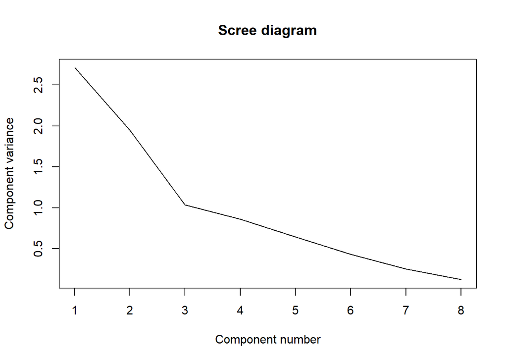

```r
names(eigen_social_media) <- paste("PC",1:8,sep="")

plot(eigen_social_media, xlab = "Component number", ylab = "Component variance", type = "l", main = "Scree diagram")
```

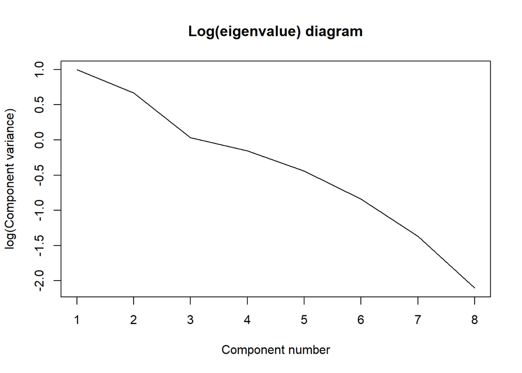

```r
plot(log(eigen_social_media), xlab = "Component number",ylab = "log(Component variance)", type="l",main = "Log(eigenvalue) diagram")
```

**Inference**:

- Based on the observed Scree plots, **3 can be chosen as the ideal number of Principal Components**.

**Biplot**

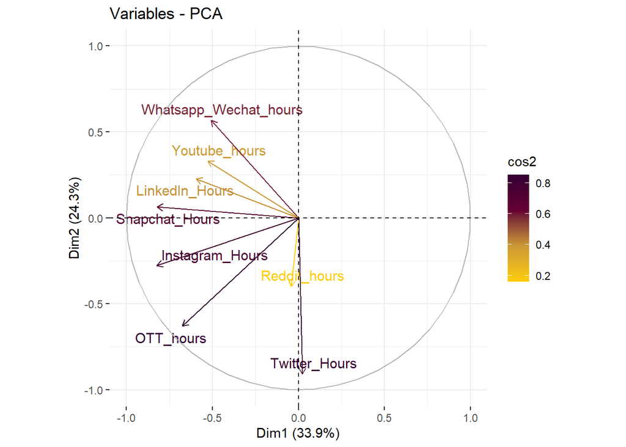

```r
fviz_pca_var(social_media_pca,col.var = "cos2",
             gradient.cols = c("#FFCC00", "#CC9933", "#660033", "#330033"),
             repel = TRUE)
```

**Inference:**

- The distance between points in a biplot show the generalised distance between them.
- The closer they are to each other, the stronger correlation they have.

**Individual PCA**

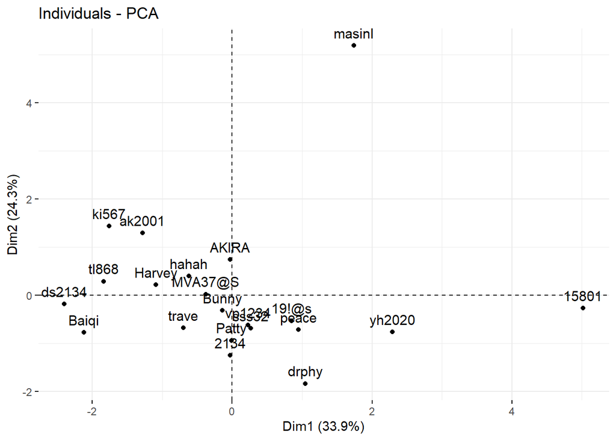

```r
res.pca <- PCA(social_media_num, graph = FALSE)

fviz_pca_ind(res.pca)
```

**Inference**:

- As we can notice, most of the students are very similar with a few outliers such as *masinl* and *15801*

**PCA - Biplot**

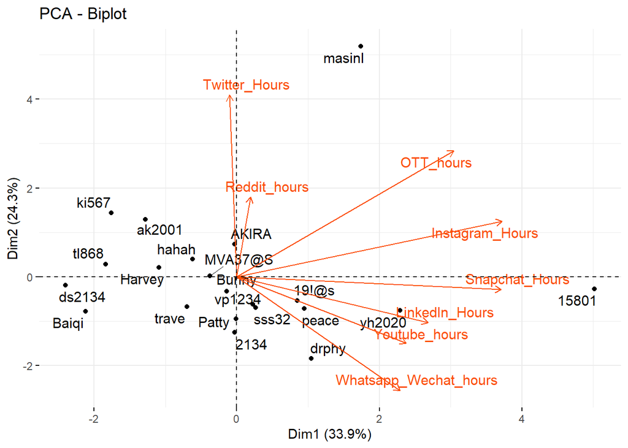

```r
fviz_pca_biplot(res.pca, repel = TRUE,
                col.var = "#FC4E07", # Variables color
                )
```

**Inference:**

#### **Cluster Analysis**

```r
matstd_socialmedia <- scale(social_media_num)
```

**Elbow Plot - To identify the ideal number of clusters**

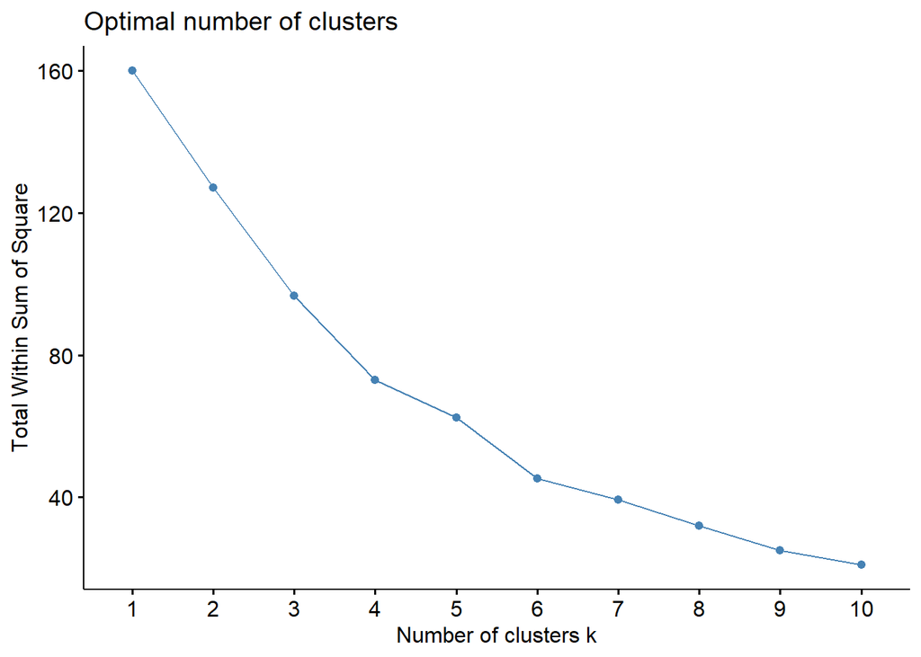

```r
fviz_nbclust(matstd_socialmedia, kmeans, method = "wss")
```

**Inference:**

- It can be observed that **4 may be the ideal number of clusters**

**Dendogram - To visualize the different possible clusters**

```r
dist.sm <- dist(matstd_socialmedia, method = "euclidean")
clussm.nn <- hclust(dist.sm, method = "single")
```

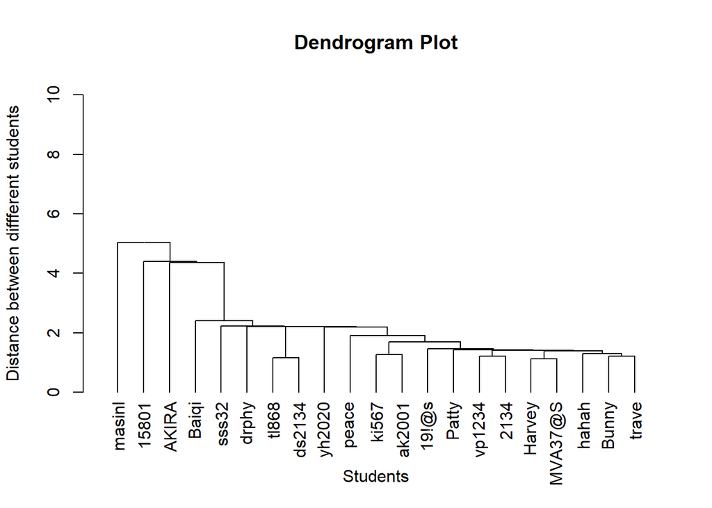

```r
plot(as.dendrogram(clussm.nn),xlab="Students",ylab="Distance between diffferent students",ylim=c(0,10),
     main="Dendrogram Plot")
```

**Membership of all clusters**

```r
set.seed(123)
kmeans4.sm <- kmeans(matstd_socialmedia, 4, nstart = 25)

kmeans4.sm
```

```
## K-means clustering with 4 clusters of sizes 1, 1, 8, 11
##
## Cluster means:
##   Instagram_Hours LinkedIn_Hours Snapchat_Hours Twitter_Hours
## 1      1.66012348      0.1567109    -0.16267631     3.4244909
## 2      2.47106942      0.1365706     3.31403861    -0.4497850
## 3     -0.61342140     -0.8558441    -0.42122948     0.2204647
## 4      0.07056166      0.5957701     0.01986123    -0.4307658
##   Whatsapp_Wechat_hours Reddit_hours Youtube_hours  OTT_hours
## 1            -1.3459283    1.2381055    -0.2854165  3.4417324
## 2             2.1373721   -0.3334743     1.2670048  2.1642630
## 3            -0.5612755   -0.2438942    -0.7085389 -0.3974180
## 4             0.3362509    0.0951384     0.4260657 -0.2206047
##
## Clustering vector:
##  masinl   peace   Patty   Bunny   tl868   drphy   trave   19!@s  yh2020  ds2134
##       1       4       4       4       3       4       4       4       4       3
##   ki567  ak2001  Harvey   hahah   AKIRA  vp1234   sss32 MVA37@S    2134   15801
##       3       3       3       3       4       4       4       3       4       2
##   Baiqi
##       3
##
## Within cluster sum of squares by cluster:
## [1]  0.00000  0.00000 21.39991 51.68132
##  (between_SS / total_SS =  54.3 %)
##
## Available components:
##
## [1] "cluster"      "centers"      "totss"        "withinss"     "tot.withinss"
## [6] "betweenss"    "size"         "iter"         "ifault"
```

```r
clus1 <- matrix(names(kmeans4.sm$cluster[kmeans4.sm$cluster == 1]),
                ncol=1, nrow=length(kmeans4.sm$cluster[kmeans4.sm$cluster == 1]))
colnames(clus1) <- "Cluster 1"

clus2 <- matrix(names(kmeans4.sm$cluster[kmeans4.sm$cluster == 2]),
                ncol=1, nrow=length(kmeans4.sm$cluster[kmeans4.sm$cluster == 2]))
colnames(clus2) <- "Cluster 2"

clus3 <- matrix(names(kmeans4.sm$cluster[kmeans4.sm$cluster == 3]),
                ncol=1, nrow=length(kmeans4.sm$cluster[kmeans4.sm$cluster == 3]))
colnames(clus3) <- "Cluster 3"

clus4 <- matrix(names(kmeans4.sm$cluster[kmeans4.sm$cluster == 4]),
                ncol=1, nrow=length(kmeans4.sm$cluster[kmeans4.sm$cluster == 4]))
colnames(clus4) <- "Cluster 4"

list(clus1,clus2, clus3, clus4)
```

```
## [[1]]
##      Cluster 1
## [1,] "masinl"
##
## [[2]]
##      Cluster 2
## [1,] "15801"
##
## [[3]]
##      Cluster 3
## [1,] "tl868"
## [2,] "ds2134"
## [3,] "ki567"
## [4,] "ak2001"
## [5,] "Harvey"
## [6,] "hahah"
## [7,] "MVA37@S"
## [8,] "Baiqi"
##
## [[4]]
##       Cluster 4
##  [1,] "peace"
##  [2,] "Patty"
##  [3,] "Bunny"
##  [4,] "drphy"
##  [5,] "trave"
##  [6,] "19!@s"
##  [7,] "yh2020"
##  [8,] "AKIRA"
##  [9,] "vp1234"
## [10,] "sss32"
## [11,] "2134"
```

**Inference:**

- The students that fall into the 4 different clusters can be viewed.

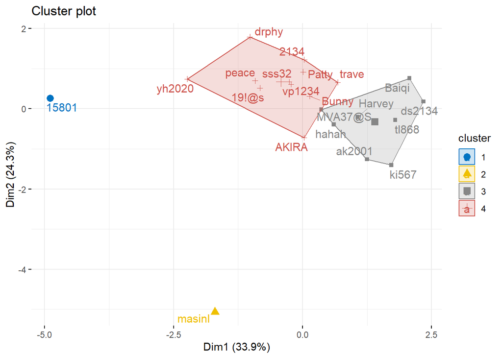

```r
km.res <- kmeans(matstd_socialmedia, 4, nstart = 25)
# Visualize
fviz_cluster(km.res, data = matstd_socialmedia,
             ellipse.type = "convex",
             palette = "jco",
             ggtheme = theme_minimal(),
             repel = TRUE)
```

**Inference:**

#### **Factor Analysis**

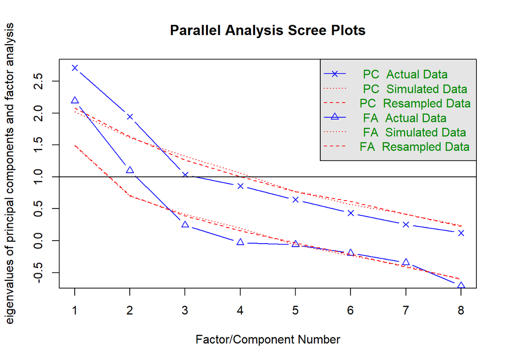

```
## Parallel analysis suggests that the number of factors =  2  and the number of components =  2
```

```r
fa.parallel(social_media_num)
```

**Inference**:

- Following the FA Actual Data, we can interpret as **2 to be the ideal number of factors**.

**Factor Model**

```r
fit.pc <- principal(social_media_num, nfactors=2, rotate="varimax")

round(fit.pc$values, 3)
```

```
## [1] 2.710 1.945 1.035 0.858 0.642 0.433 0.254 0.122
```

```r
fit.pc$loadings
```

```
##
## Loadings:
##                       RC1    RC2
## Instagram_Hours        0.741  0.457
## LinkedIn_Hours         0.632
## Snapchat_Hours         0.816  0.125
## Twitter_Hours         -0.227  0.879
## Whatsapp_Wechat_hours  0.624 -0.438
## Reddit_hours                  0.399
## Youtube_hours          0.589 -0.202
## OTT_hours              0.515  0.767
##
##                  RC1   RC2
## SS loadings    2.671 1.984
## Proportion Var 0.334 0.248
## Cumulative Var 0.334 0.582
```

**Inference:**

- The loadings give the correlation, and leave out the values that may be way below a threshold making it unimportant.
- An inference of how heavily correlated *Snapchat_Hours*, *Instagram_Hours* are to *RC1* can be drawn.
- Similarly, *Twitter_Hours*, and *OTT_Hours* are to *RC2*.

```r
fit.pc$communality
```

```
##       Instagram_Hours        LinkedIn_Hours        Snapchat_Hours
##             0.7587068             0.4067641             0.6818762
##         Twitter_Hours Whatsapp_Wechat_hours          Reddit_hours
##             0.8250142             0.5813503             0.1612115
##         Youtube_hours             OTT_hours
##             0.3874757             0.8530005
```

**Inference:**

- The column with the lowest communality scores can be referenced to be the least contributing.
- In this case, it can be observed that *Reddit_Hours* has the least communality score making it the least contributing column.

```r
fit.pc$scores
```

```
##                RC1          RC2
## masinl   0.1810484  3.771824071
## peace    0.6589265 -0.359594601
## Patty    0.1439466 -0.642302452
## Bunny   -0.0296617 -0.237929166
## tl868   -1.1073374 -0.051545715
## drphy    0.8961778 -1.110483298
## trave   -0.2958547 -0.553853942
## 19!@s    0.5736439 -0.248665075
## yh2020   1.4446994 -0.210099340
## ds2134  -1.3563033 -0.448489201
## ki567   -1.2452391  0.742742138
## ak2001  -0.9435472  0.707985952
## Harvey  -0.6636204 -0.002185152
## hahah   -0.4202364  0.189292093
## AKIRA   -0.1326074  0.499627563
## vp1234   0.2312653 -0.393215229
## sss32    0.2635889 -0.433601214
## MVA37@S -0.2186578 -0.036239858
## 2134     0.1805232 -0.858490060
## 15801    2.9405807  0.490722385
## Baiqi   -1.1013353 -0.815499899
```

**Inference:**

- The scores here are representing the transformed data corresponding to each row (student).

**Visualizing the Columns that go into each Factor**

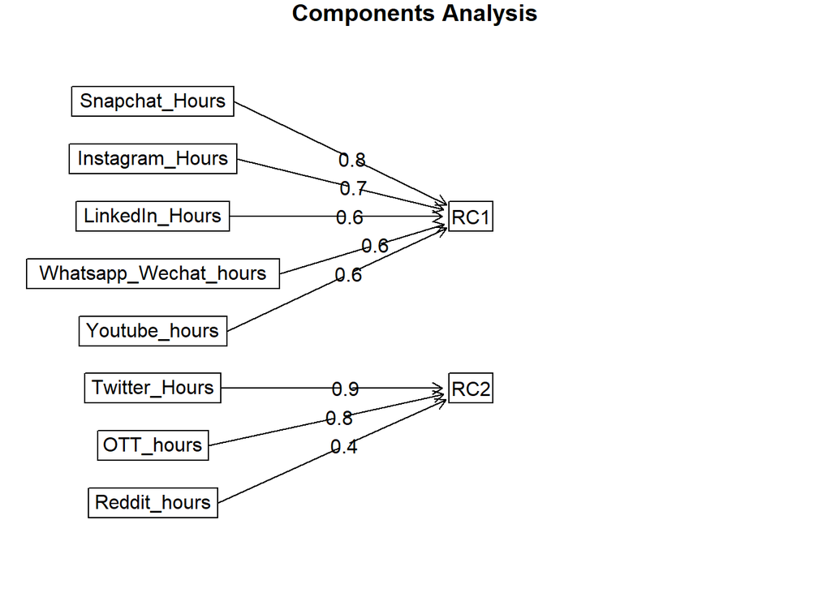

```r
fa.diagram(fit.pc)
```

**Inference:**

- The diagram is clearly representing how *Snapchat_Hours*, *Instagram_Hours* are heavily contributing to *RC1* whereas *LinkedIn_Hours*, *Whatsapp_Wechat_hours*, *Youtube_hours* contribute equally. This is indicative of how these applications are viewed more or less in similar patterns, making them more popular among students.
- *Twitter_Hours*, *OTT_Hours* are bigger contributors to *RC2*, whereas *Reddit_hours* contribute least. This showcases that Reddit is the least popular application, and Twitter, OTT are popular among a few students.

### **Summarization of Model Results with respect to myself and the class**

**In order to understand where I stand w.r.t to the other students, Z-scores can be calculated**

```r
means <- colMeans(social_media_num)
std_devs <- apply(social_media_num, 2, sd)

z_scores <- scale(social_media_num, center = means, scale = std_devs)

z_scores[18,]
```

```
##       Instagram_Hours        LinkedIn_Hours        Snapchat_Hours
##            0.19179943           -0.68112674            0.31592211
##         Twitter_Hours Whatsapp_Wechat_hours          Reddit_hours
##           -0.44978498            0.09836697           -0.33347426
##         Youtube_hours             OTT_hours
##           -1.27756549            0.02379202
```

- The Z-scores can help me identify how my **Youtube**, **LinkedIn**, and **Twitter** usage are **way below** my fellow classmates.
- Whereas **Instagram** is **slightly higher** than the average among my classmates.